# Cyclistic 2025 – Análisis de Comportamiento y Recomendaciones Estratégicas

Nadina Díaz

12-02-2026

## 1 Introducción

La empresa bicicletas compartidas de Chicago, **Cyclistic** quiere aumentar la rentabilidad y para lograr esto quieren transformar los socios ocasionales en socios anuales, ya que los analistas financieros concluyeron que estos eran más valiosos desde el punto de vista financiero. El propósito de este proyecto es analizar los patrones de uso y comportamiento de los usuarios ocasionales y los usuarios anuales para detectar el uso que le dan a las bicicletas de Cyclistic. Esto permitirá diseñar estrategia de marketing para convertir a los usuarios ocasionales en usuarios anuales

## 2 Fuentes de Datos Utilizadas

Para identificar los patrones de uso de las bicicletas, se utilizaron los datos de viajes de Cyclistic correspondientes a los **últimos doce meses disponibles** a la fecha del análisis (enero de 2026). Este período abarca los registros históricos completos del año 2025. La selección de un período anual completo permite reducir el sesgo estacional y contar con información reciente y representativa, adecuada para respaldar la toma de decisiones actuales.

*Los datos son públicos y han sido proporcionados por Motivate International Inc.*

## 3 Preparación de los Datos (Setting up)

```r
library(tidyverse)
library(lubridate)
```

## 4 Limpieza y Procesamiento de Datos

```r
# Limpieza y Transformación Definitiva

tabla_final <- tabla_maestra %>%

  # === Variables temporales ===
  mutate(
    ride_duration_min = as.numeric(difftime(ended_at, started_at, units = "mins")),
    dow_num  = wday(started_at, week_start = 1),
    month_num = month(started_at),
    hour = hour(started_at),

   # Día de la semana (factor ordenado)
    day_of_week = factor(
      c("lunes","martes","miercoles","jueves","viernes","sabado","domingo")[dow_num],
      levels = c("lunes","martes","miercoles","jueves","viernes","sabado","domingo")
    ),

    # Mes (factor ordenado)
    month = factor(
      c("enero","febrero","marzo","abril","mayo","junio",
        "julio","agosto","septiembre","octubre","noviembre","diciembre")[month_num],
      levels = c("enero","febrero","marzo","abril","mayo","junio",
                 "julio","agosto","septiembre","octubre","noviembre","diciembre")
    )
  ) %>%

  # === Remover duplicados por ID ===
  distinct(ride_id, .keep_all = TRUE) %>%

    # === Filtrar viajes inválidos ===
  filter(
    ride_duration_min >= 1,
    ride_duration_min <= 300
  ) %>%

 # === Remover columnas no utilizadas ===
  select(-start_lat, -start_lng, -end_lat, -end_lng)
```

Se aplicó un filtro para excluir viajes menores a 1 minuto (falsos inicios) y mayores a 5 horas (casos atípicos), asegurando que el análisis de promedios refleje el comportamiento real de uso del servicio

## 5 Análisis Exploratorio

### 5.1 Distribución general de usuarios

```r
tabla_final %>%
  group_by(member_casual) %>%
  summarise(
    cantidad_viajes = n(),
    promedio_duracion = mean(ride_duration_min),
    median_duracion = median(ride_duration_min),
    porcentaje = n() / nrow(tabla_final) * 100,
    sd_duracion = sd(ride_duration_min)
  )
```

```
## # A tibble: 2 × 6
##   member_casual cantidad_viajes promedio_duracion median_duracion porcentaje
##   <chr>                   <int>             <dbl>           <dbl>      <dbl>
## 1 casual                1912566              18.7           11.9        35.5
## 2 member                3482364              11.8            8.73       64.5
## # ℹ 1 more variable: sd_duracion <dbl>
```

*Aunque los miembros representan el 64.5% del total de viajes, los usuarios casuales realizan recorridos un 58% más largos, reforzando su perfil recreativo y mostrando un alto potencial de conversión hacia planes anuales*

### 5.2 Patrones semanales

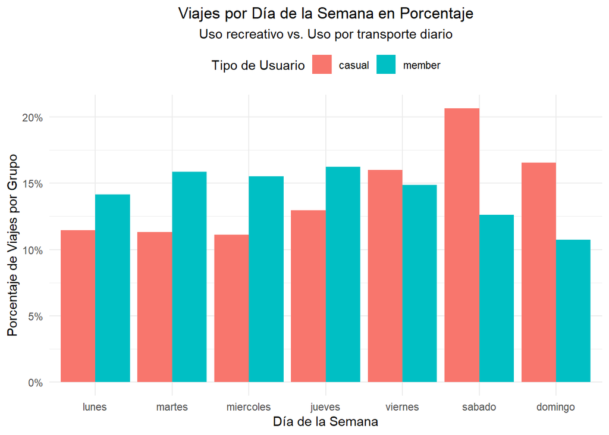

```r
tabla_final %>%
  count(day_of_week, member_casual) %>%
  group_by(member_casual) %>%
  mutate(prop = n / sum(n)) %>%

  ggplot(aes(day_of_week, prop, fill = member_casual)) +
  geom_col(position = "dodge") +
  scale_y_continuous(labels = scales::percent) +

  labs(title = "Viajes por Día de la Semana en Porcentaje",
       subtitle = "Uso recreativo vs. Uso por transporte diario",
       x = "Día de la Semana",
       y = "Porcentaje de Viajes por Grupo",
              fill= "Tipo de Usuario") +

  theme_minimal() +
  theme(legend.position = "top",
        plot.title = element_text(hjust = 0.5),
        plot.subtitle = element_text(hjust = 0.5)
        )
```

### 5.3 Patrones horarios

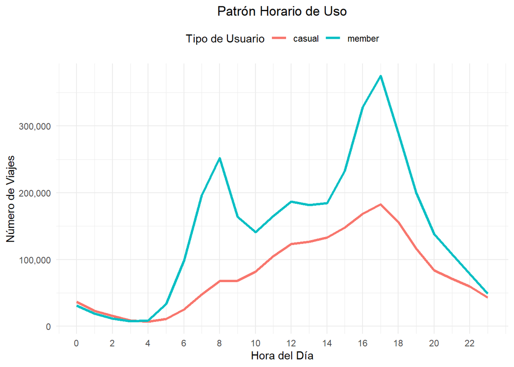

```r
tabla_final %>%
  count(hour, member_casual) %>%

  ggplot(aes(x = hour, y = n, color = member_casual)) +
  geom_line(size = 1.2) +
  scale_y_continuous(labels = scales::comma) +
  scale_x_continuous(breaks = seq(0, 23, by = 2)) +

  labs(title = "Patrón Horario de Uso",
       x = "Hora del Día",
       y = "Número de Viajes",
       color= "Tipo de Usuario") +

  theme_minimal() +
  theme(legend.position = "top",
        plot.title = element_text(hjust = 0.5),
        plot.subtitle = element_text(hjust = 0.5)
        )
```

*Los miembros presentan picos definidos en horarios laborales (8 AM y 5 PM), en tanto que los casuales muestran un incremento progresivo durante la tarde, alcanzando su máximo entre las 17–18 hs. Este comportamiento subraya un uso predominantemente recreativo o social.*

### 5.4 Estacionalidad

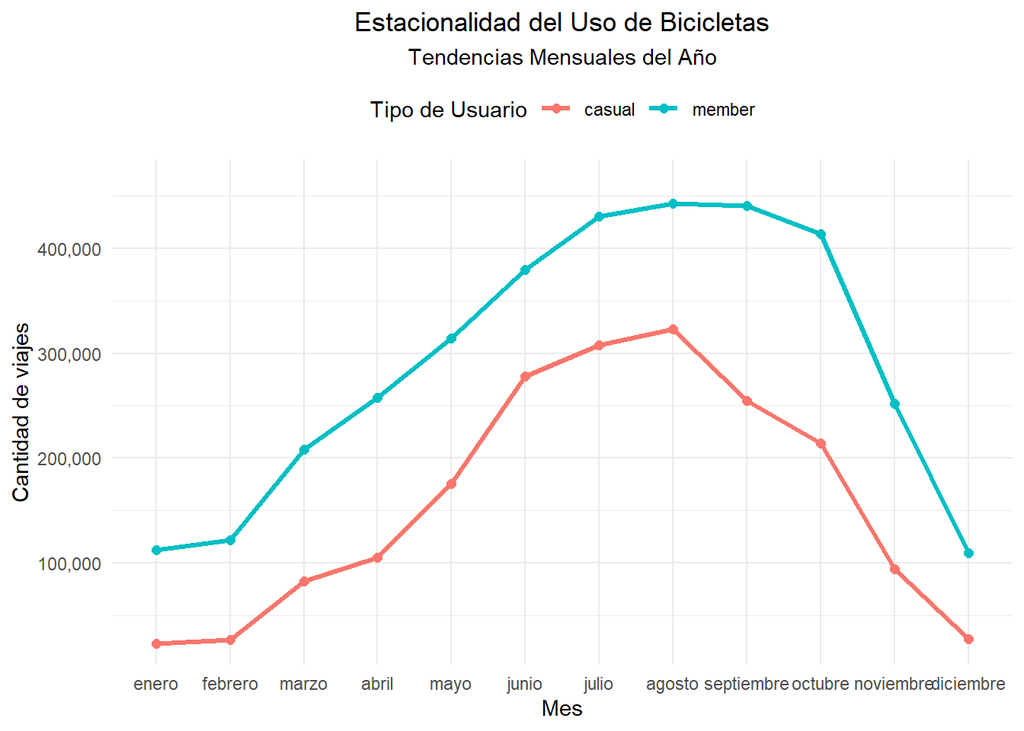

```r
tabla_final %>%
  count(month, member_casual) %>%
  ggplot(aes(x = month, y = n, color = member_casual, group = member_casual)) +
  geom_line(size = 1.2) +
  geom_point(size = 2) +
    labs(
    title = "Estacionalidad del Uso de Bicicletas",
    subtitle = "Tendencias Mensuales del Año",
    x = "Mes",
    y = "Cantidad de viajes",
    color= "Tipo de Usuario"
  ) +
  theme_minimal() +
  theme(legend.position = "top",
        plot.title = element_text(hjust = 0.5),
        plot.subtitle = element_text(hjust = 0.5)
  )+
  scale_y_continuous(labels = scales::comma, expand = expansion(mult = c(0.05, 0.1)))
```

## 6 Hallazgos clave

1. Los miembros explican el 64.5% del volumen total.
2. Los casuales muestran mayor duración promedio de viaje.
3. Picos laborales para miembros y recreativos para casuales.
4. Fuerte estacionalidad con máximo en verano.

## 7 Recomendaciones

- Implementar un comparador de costos para mostrar cuánto ahorran los casuales con una membresía anual, dado que sus viajes son 58% más largos.
- Incentivar el uso vespertino con beneficios y alianzas con comercios/turismo, aprovechando el aumento de demanda casual en ese horario.
- Ofrecer un pase exclusivo para fines de semana y feriados, alineado al pico de uso casual de los sábados, como puerta de entrada a membresías anuales.
- Realizar campañas de conversión en temporada alta, destacando que la membresía se paga sola con pocos viajes largos en verano.

## 8 Conclusiones finales

**Con un enfoque basado en datos, Cyclistic puede transformar el uso ocasional en lealtad anual, impulsando un crecimiento sostenible, predecible y alineado con los hábitos reales de sus usuarios.**